# Exploratory Analysis

# Distribution of Values

## Statistical Analysis

The data that we’re most interested in is data about the percentage of a regions population that is using unimproved drinking water.

At further inspection we can see that the standard deviation of the proportion of populations using unimproved drinking water is 7.513%. This supports our analysis that there exist countries which use unimproved water at significantly higher rates than the other regions in the world.

## Geographic Distribution

Unimproved drinking water sources include unprotected dug wells, unprotected springs, cart with small tank/drum, bottled water, tanker truck, and surface water (river, dam, lake, pond, stream, canal, irrigation channels). The data gives us significant insights on which parts of the world might be potentially affected in terms of health. We notice that the African continent has significantly higher proportions of populations using unimproved sources of drinking water. Causes of health burden across the world measured against the data on proportions of population using unimproved water sources can bring to light the countries that are most affected by this particular indicator and would thus help in better development of strategies for devicing solutions (starting from improving water sources).

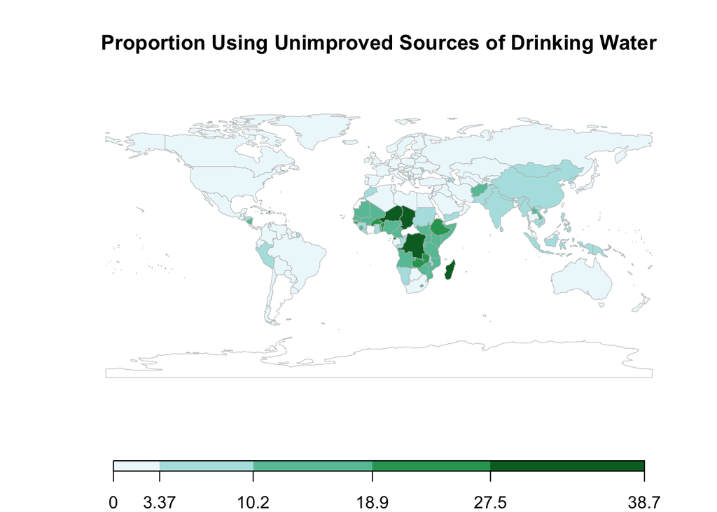

## Common Causes of Health Burden

The plot below is a histogram of the most frequent diseases found in the bottom 10% of countries with the lowest access to clean drinking water. Countries were ranked based on the proportion of their population that is reliant on an unimproved water source. For each of the countries within the bottom 10%, the top 10 causes which contributed the most to their DALYs were selected and aggregated to create a count of significant causes of health burden among countries with low access to clean drinking water.

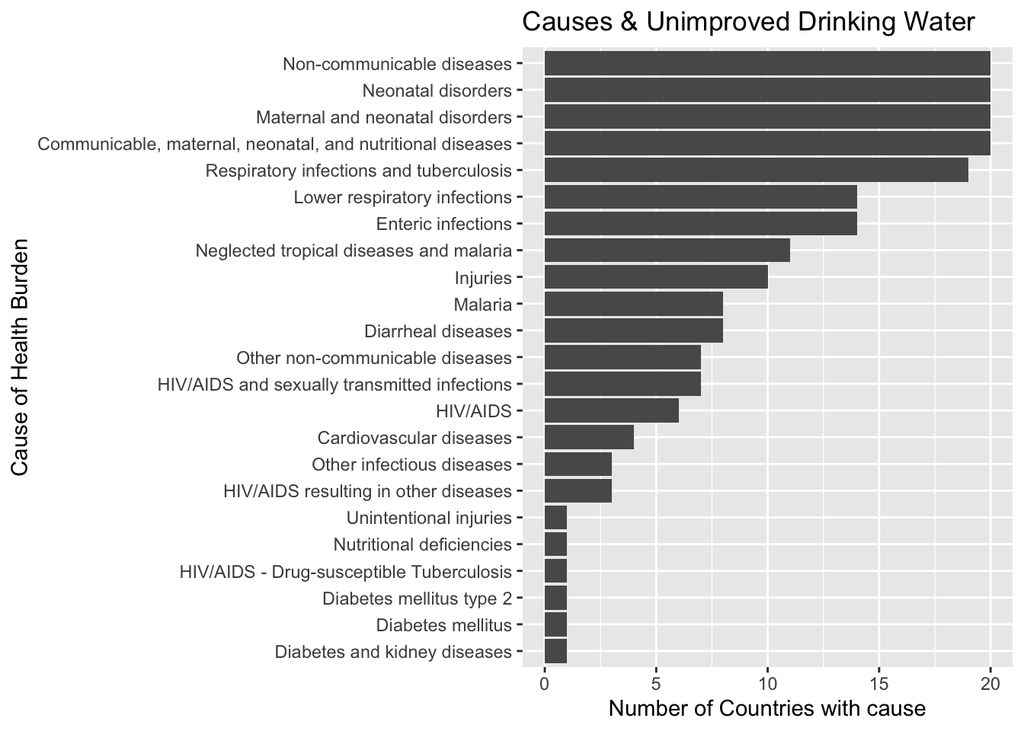

### Interpretation

# Relationships Between Variables

# Relationships of DALYs rate and water quality of top 8 DALYS rate countries

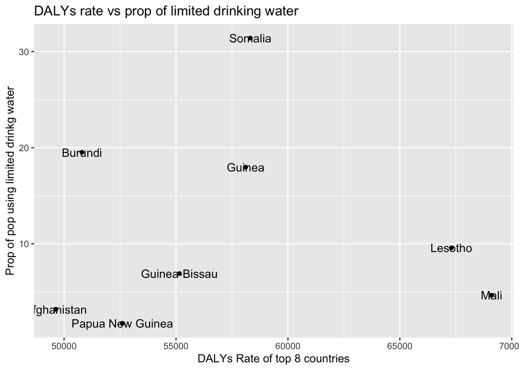

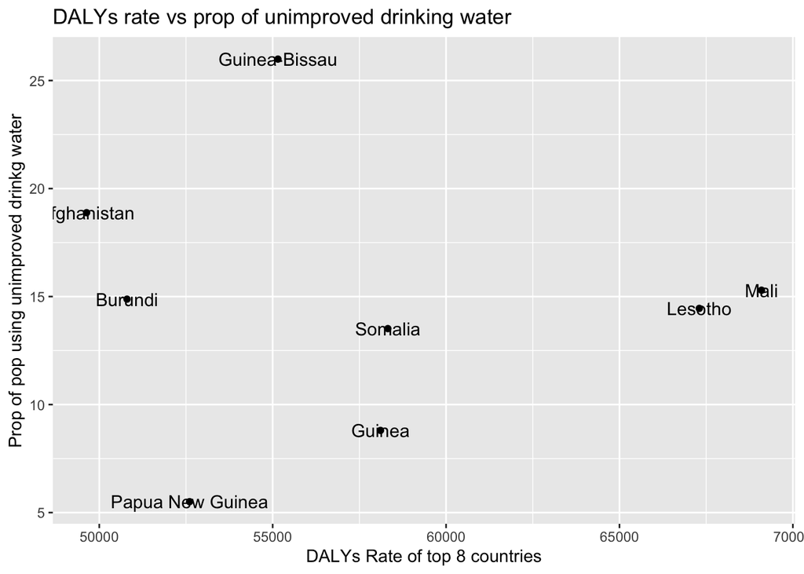

## Plots of relationship between various causes & water access measured by DALYS

The purpose of these plots is to explore if there is a correlation between limited drinking water access and diseases or infections that may be associated with that. If there is a relationship then we can look into causal effects and this provides a good visual for how strong that relationship may be. In this dataset, **limited drinking water access is defined as water collection from an improved source exceeded 30 minutes**. Some of the causes we looked at were based on background information regarding water collection, such as women and girls bear the majority of the burden of water collection so we wanted to examine the relationship between maternal sepsis and other maternal infections.

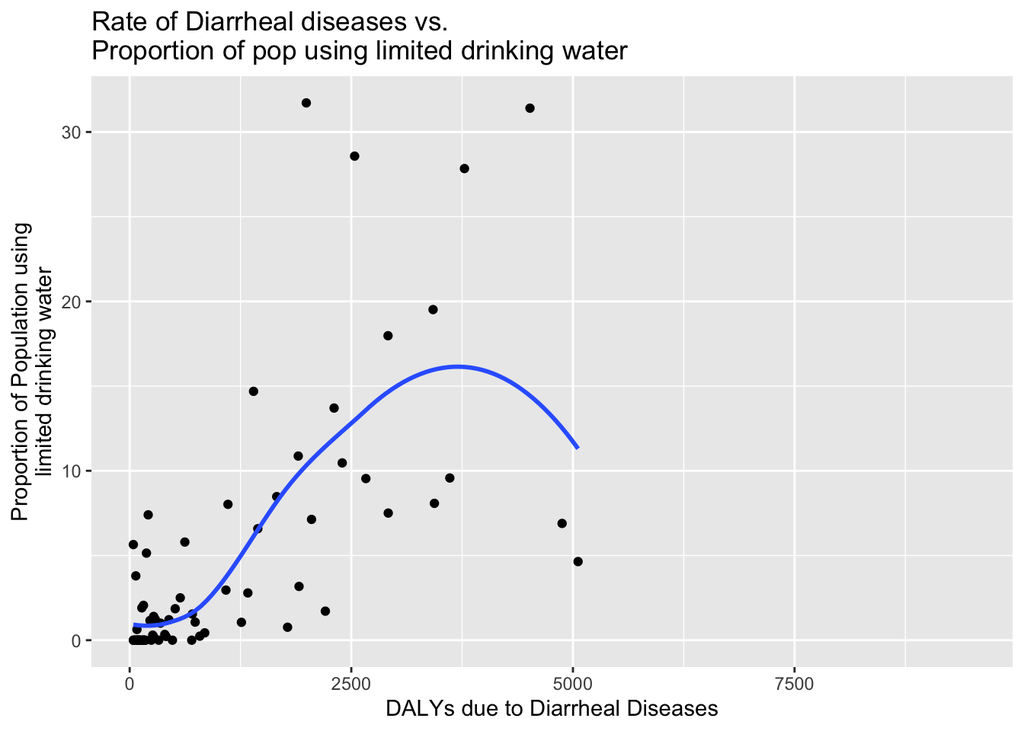

This plot shows the relationship between diarrheal disease and proportion of the population using limited drinking water. There is a trend upward, as the proportion of the population with limited drinking water increases, DALYs due to diarrheal diseases also increases with a few outliers. This is expected becauase some diarrheal diseases are caused by poor water quality.

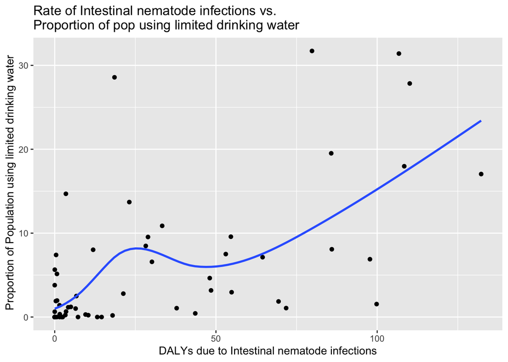

The plot above shows the relationship between intestinal nematode infections and access to drinking water. The graph shows an upward trend, similar to diarrheal diseases. The greater percentage of the population with limited access to drinking water, the higher the DALYs due to nematode infections.

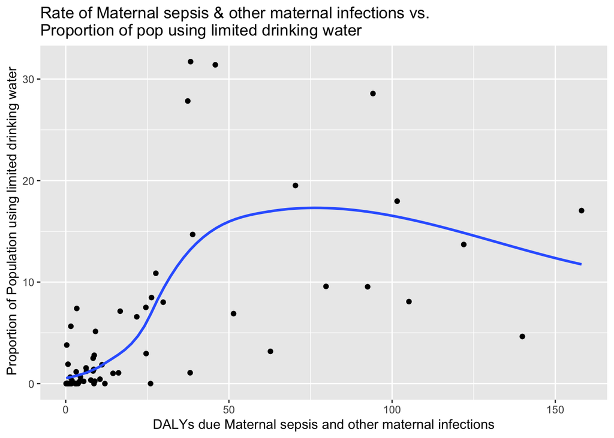

The plot above shows the relationship between maternal sepsis and other maternal infections and access to drinking water. As mentioned before, the burden of getting water falls unevenly on women and girls, so we decided to explore this area. The trend line shows an increase and then it plateaus, which is indicative of an unclear relationship. The points are somewhat scattered compared to the two previous causes and call for further investigation.

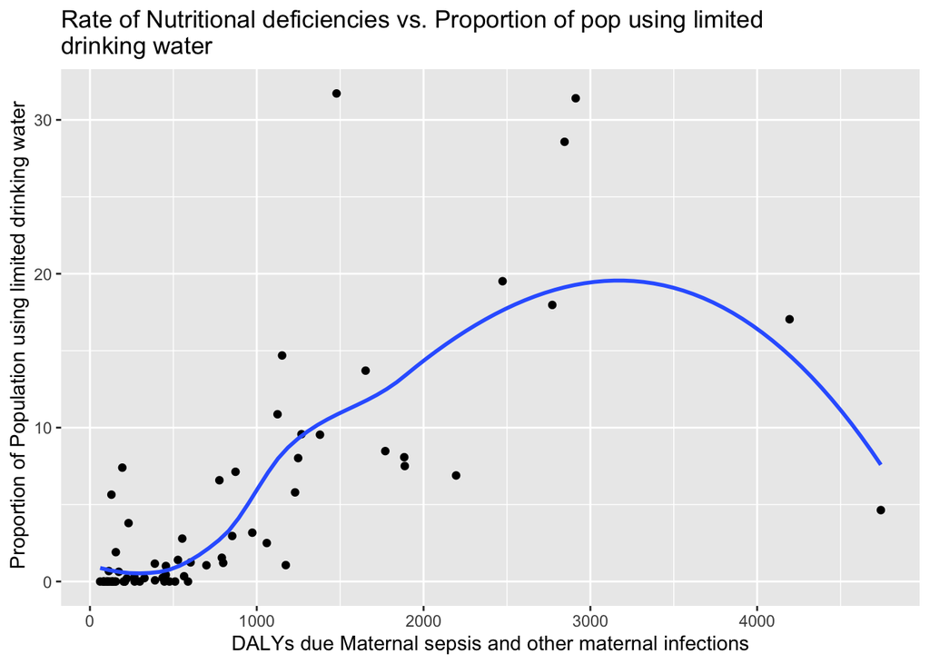

The plot above shows the relationship between nutritional deficiencies and access to drinking water. This graph follows a similar pattern to the maternal sepsis and other maternal infections graph with an increase and then a dropoff, which is likely caused by overfitting to an outlier (Mali). In Mali, there is one clear point which has a high rate of maternal sepsis and infection but access to limited drinking water is not as high as the rest of the plot would predict. This goes to show that these plots represent correlation much more than they do causation, and any insights gathered require more analysis to be able to accurately make statements regarding them.